# Data Visualization in R

AAA

15 de enero de 2018

# Course Description

This course provides a comprehensive introduction on how to plot data with R’s default graphics system, base graphics.

After an introduction to base graphics, we look at a number of R plotting examples, from simple graphs such as scatterplots to plotting correlation matrices. The course finishes with exercises in plot customization. This includes using R plot colors effectively and creating and saving complex plots in R.

Base Graphics Background R supports four different graphics systems: base graphics, grid graphics, lattice graphics, and ggplot2. Base graphics is the default graphics system in R, the easiest of the four systems to learn to use, and provides a wide variety of useful tools, especially for exploratory graphics where we wish to learn what is in an unfamiliar dataset.

## Packages requirements

```r
#install.packages("robustbase")
#install.packages("insuranceData")
#install.packages("car")
#install.packages("aplpack")
#install.packages("corrplot")
#install.packages("rpart")
#install.packages("wordcloud")
#install.packages("RColorBrewer")
#install.packages("gridExtra")
#install.packages("tabplot")
#install.packages("lattice")
#install.packages("ggplot2")
```

## A quick introduction to base R graphics

This chapter gives a brief overview of some of the things you can do with base graphics in R. This graphics system is one of four available in R and it forms the basis for this course because it is both the easiest to learn and extremely useful both in preparing exploratory data visualizations to help you see what’s in a dataset and in preparing explanatory data visualizations to help others see what we have found.

### Creating an exploratory plot array

In this exercise, you’ll construct a simple exploratory plot from a data frame that gives values for three variables, recorded over two winter heating seasons. The variables are:

Temp: a measure of the outside temperature during one week Gas: the amount of heating gas consumed during that week Insul: a categorical variable with two values, indicating whether the measurements were made before or after an insulation upgrade was made to the house

### INSTRUCTIONS

Load the MASS package to make the whiteside data frame available. Apply the plot() function to the whiteside data frame.

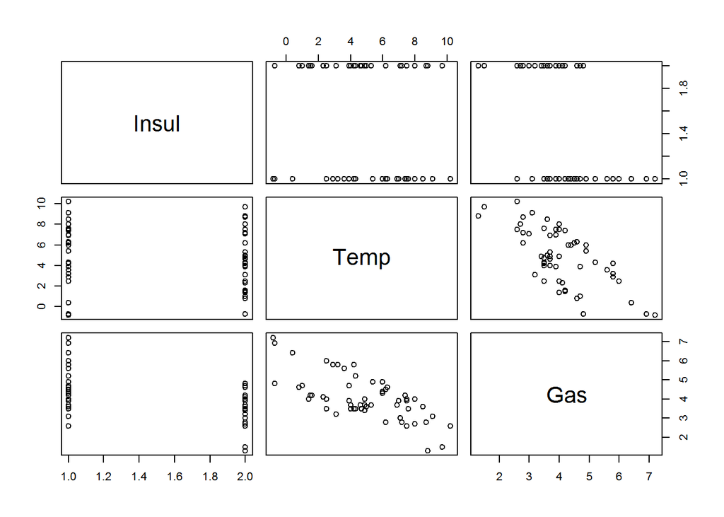

```r
# Load MASS package
library("MASS")

# Plot whiteside data
plot(whiteside)
```

### Creating an explanatory scatterplot

In constrast to the exploratory analysis plot you created in the previous exercise, this exercise asks you to create a simple explanatory scatterplot, suitable for sharing with others.

Here, it is important to make editorial choices in constructing this plot, rather than depending entirely on default options. In particular, the important editorial aspects of this plot are: first, the variables to be plotted, and second, the axis labels, which are specified as strings to the xlab and ylab arguments to the plot() function.

### INSTRUCTIONS

Use the plot() function to construct a scatterplot of the heating gas consumption, Gas, versus the outside temperature, Temp, from the whiteside data frame. Label the x- and y-axes to indicate the variables in the plot (i.e. “Outside temperature” and “Heating gas consumption”, respectively.)

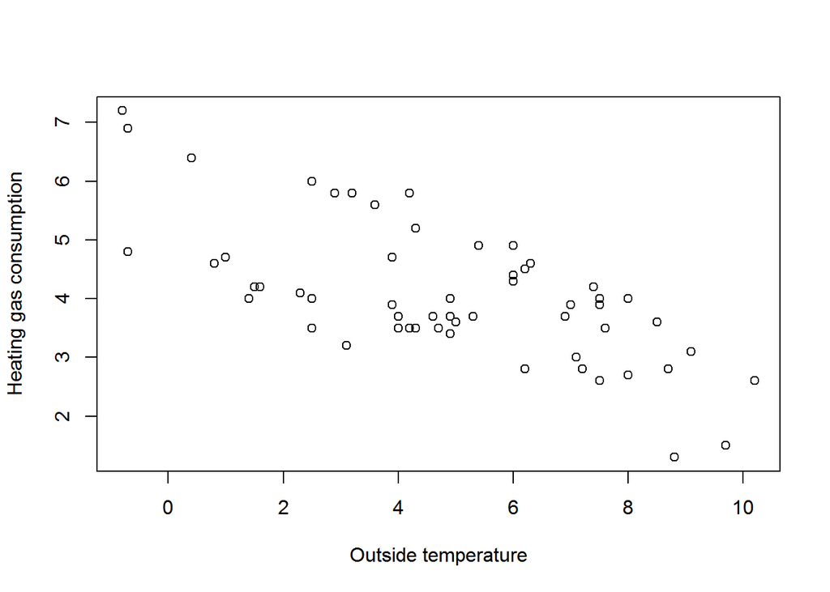

```r
# Plot Gas vs. Temp
plot(whiteside$Temp, whiteside$Gas, ylab="Heating gas consumption", xlab="Outside temperature")
```

### The plot() function is generic

One of the key features of the plot() function is that it is generic, meaning that the results of applying the function depend on the nature of the object to which it is applied.

In the first exercise of this chapter, applying the plot() function to the whiteside data frame resulted in a plot array. Here, we obtain a fundamentally different kind of result when we apply the same function to Insul, a factor variable from the same data frame.

### INSTRUCTIONS

Apply the plot() function to the Insul variable from the whiteside data frame.

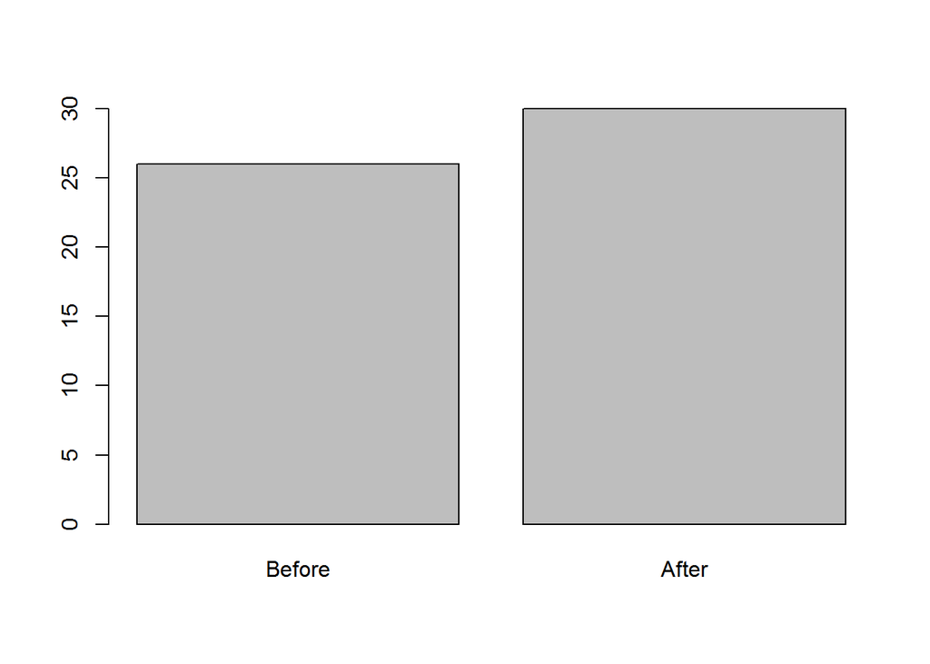

```r
# Apply the plot() function to Insul
plot(whiteside$Insul)
```

### Adding details to a plot using point shapes, color, and reference lines

Adding additional details to your explanatory plots can help emphasize certain aspects of your data. For example, by specifying the pch and col arguments to the plot() function, you can add different point shapes and colors to show how different variables or subsets of your data relate to each other. In addition, you can add a new set of points to your existing scatterplot with the points() function, and add reference lines with the abline() function.

This exercise asks you to use these methods to create an enhanced scatterplot that effectively shows how three variables in the Cars93 data frame relate to each other. These variables are:

Price: the average sale price for a car Max.Price: the highest recorded price for that car Min.Price: the lowest recorded price for that car

### INSTRUCTIONS

Load the MASS package to make the Cars93 data frame available. Use the plot() function to create a scatterplot of the Max.Price variable versus the Price variable, specifying the pch and col parameters so the data points are represented as red solid triangles. The pch value to plot solid triangles is 17. Use the points() function to add a second set of points to your scatterplot, representing Min.Price versus Price, where the new data points are represented as blue solid circles. The pch value for solid circles is 16. Use the abline() function to add a dashed equality reference line (i.e., a line with y-intercept 0 and slope 1). See abline() to learn what arguments a and b refer to.

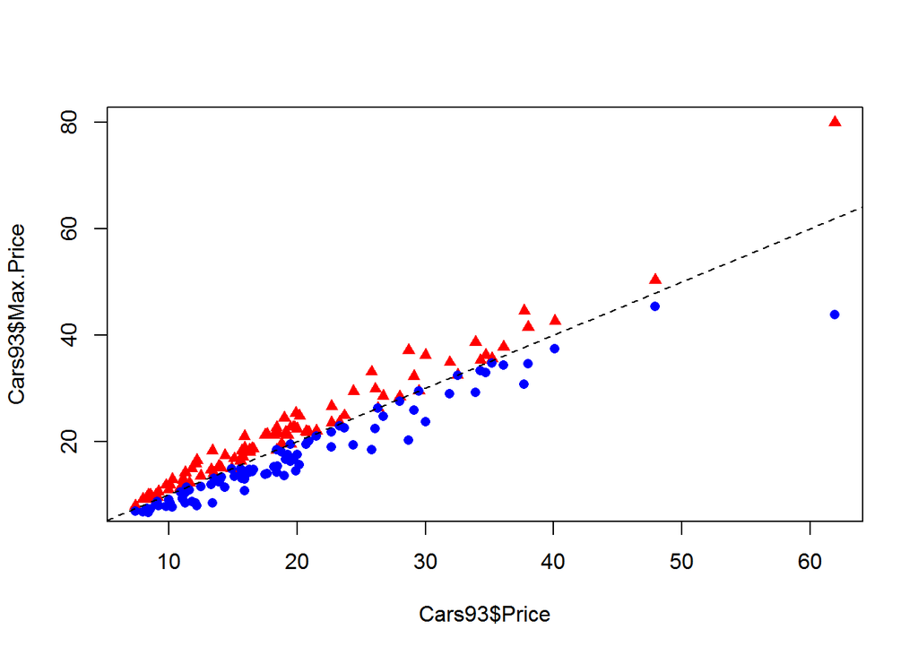

```r
# Load the MASS package
library("MASS")

# Plot Max.Price vs. Price as red triangles
plot(Cars93$Price, Cars93$Max.Price, pch = 17, col = "red" )

# Add Min.Price vs. Price as blue circles
points(Cars93$Price, Cars93$Min.Price, pch = 16, col = "blue" )

# Add an equality reference line with abline()
abline(a = 0, b = 1, lty = 2)
```

### Creating multiple plot arrays

You can plot multiple graphs on a single pane using the par() function with its mfrow parameter. For example, par(mfrow = c(1, 2)) creates a plot array with 1 row and 2 columns, allowing you to view two graphs side-by-side. This way, you can compare and contrast different datasets or different views of the same dataset. This exercise asks you to compare two views of the Animals2 dataset from the robustbase package, differing in how its variables are represented.

The objective of this exercise is to emphasize that the original representation of the variables that we have in a dataset is not always the best one for visualization or analysis. By representing the original variables in log scale, for example, we can better see and understand the data.

### INSTRUCTIONS

Load the robustbase package to make the Animals2 data frame available. Use the par() function and set the mfrow parameter to create a side-by-side plot array with 1 row and 2 columns. Use the plot() function to create a scatterplot of the variables brain versus body from this data frame, without specifying additional arguments. See what happens when you run title(“Original representation”) after your first call to plot(). Use the plot() function again, but this time with log = “xy”, to generate a plot of both the x and y variables in log scale. Use the title() function to add “Log-log plot” as the title to the second plot. Take Hint (-30xp)

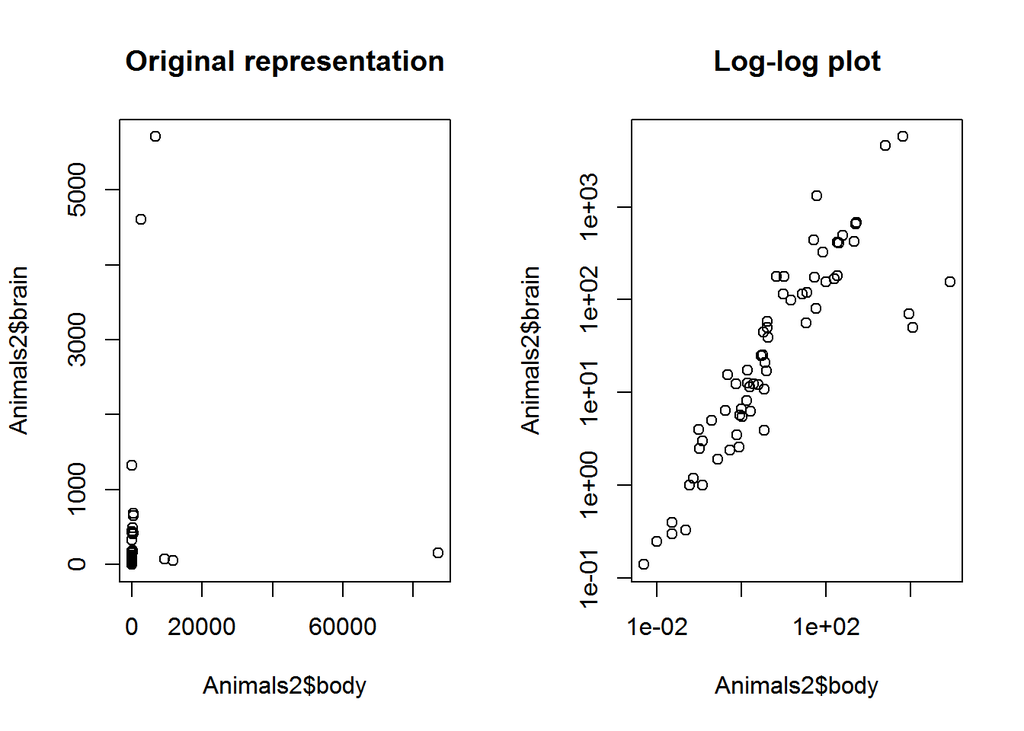

```r
# Load the robustbase package
library("robustbase")

# Set up the side-by-side plot array
par(mfrow = c(1,2))

# First plot: brain vs. body in its original form
plot(Animals2$body, Animals2$brain)

# Add the first title
title("Original representation")

# Second plot: log-log plot of brain vs. body
plot(Animals2$body, Animals2$brain, log="xy")

# Add the second title
title("Log-log plot")
```

### Avoid pie charts

The same dataset can be displayed or summarized in many different ways, but some are much more suitable than others.

Despite their general popularity, pie charts are often a poor choice. Though R allows pie charts with the pie() function, even the help file for this function argues against their use. Specifically, the help file includes a “Note” that begins with the words: “Pie charts are a very bad way of displaying information.”

Bar charts are a recommended alternative and, in this exercise, you’ll see why.

### INSTRUCTIONS

Load the insuranceData package and use the data() function to load the dataCar data frame from this package. Use the par() function and set the mfrow parameter to create a side-by-side plot array with 1 row and 2 columns. Use the table() function and the sort() function to create a table of counts of the distinct levels of the veh_body variable in the dataCar data frame, in decreasing order. Call this table tbl. Pass tbl to the pie() function to create a pie chart representation of this data as the left-hand plot. Use title() to title this plot “Pie chart”. Similarly, use the barplot() and title() functions to create a barplot representation of the same data, specifying las = 2 to make both sets of labels perpendicular to the axes, and using cex.names = 0.5 to make the name labels half the default size. Title this plot “Bar chart”.

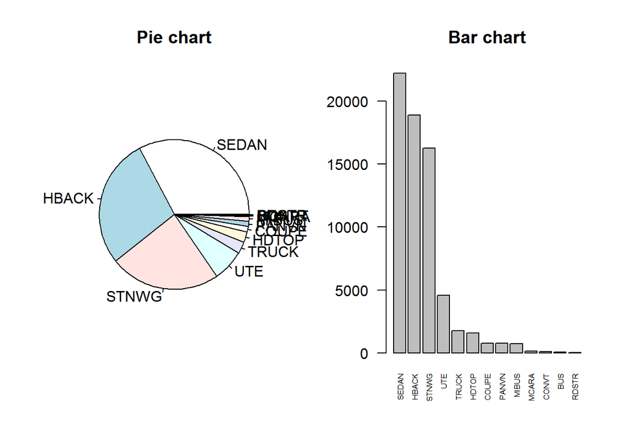

```r
# Load the insuranceData package
library("insuranceData")

# Use the data() function to get the dataCar data frame
data(dataCar)

# Set up a side-by-side plot array
par(mfrow = c(1,2))

# Create a table of veh_body record counts and sort
tbl <- sort(table(dataCar$veh_body),
            decreasing = TRUE)

# Create the pie chart and give it a title
pie(tbl)
title("Pie chart")

# Create the barplot with perpendicular, half-sized labels
barplot(tbl, las = 2, cex.names = 0.5)

# Add a title
title("Bar chart")
```

### Different plot types

Base R graphics supports many different plot types and this chapter introduces several of them that are particularly useful in seeing important features in a dataset and in explaining those features to others. We start with simple tools like histograms and density plots for characterizing one variable at a time, move on to scatter plots and other useful tools for showing how two variables relate, and finally introduce some tools for visualizing more complex relationships in our dataset.

### The hist() and truehist() functions

Histograms are probably the best-known way of looking at how the values of a numerical variable are distributed over their range, and R provides several different histogram implementations.

The purpose of this exercise is to introduce two of these:

hist() is part of base R and its default option yields a histogram based on the number of times a record falls into each of the bins on which the histogram is based. truehist() is from the MASS package and scales these counts to give an estimate of the probability density.

### INSTRUCTIONS

Use the par() function to set the mfrow parameter for a side-by-side array of two plots. Use the hist() function to generate a histogram of the Horsepower variable from the Cars93 data frame. Set its main argument equal to the title of the plot, “hist() plot”. Use the truehist() function to generate an alternative histogram of the same variable. Title this plot, “truehist() plot” by specifying its main argument accordingly.

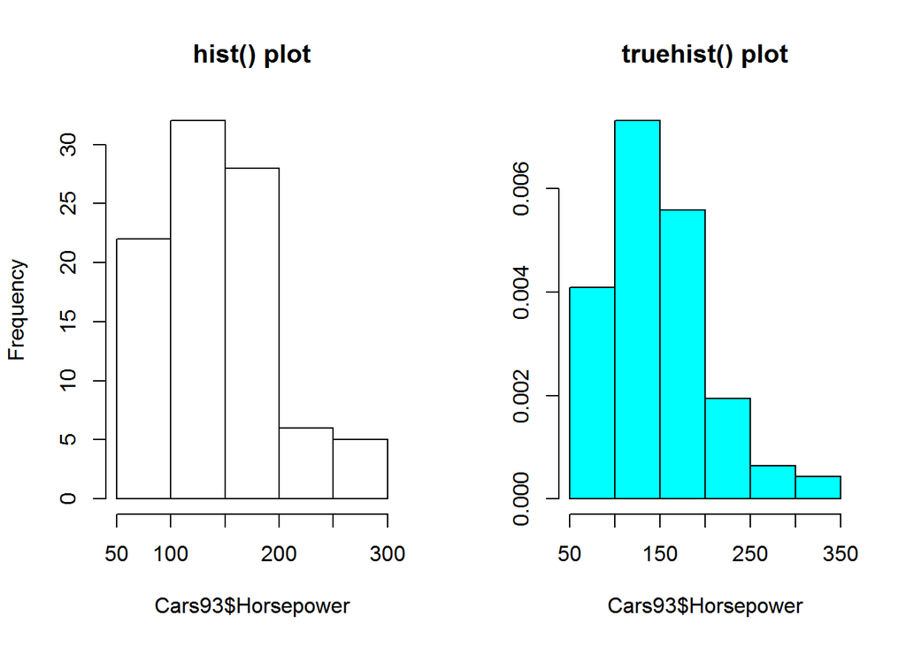

```r
# Set up a side-by-side plot array
par(mfrow = c(1,2))

# Create a histogram of counts with hist()
hist(Cars93$Horsepower, main="hist() plot")
# Create a normalized histogram with truehist()
truehist(Cars93$Horsepower, main="truehist() plot")
```

### Density plots as smoothed histograms

While they are probably not as well known as the histogram, density estimates may be regarded as smoothed histograms, designed to give a better estimate of the density function for a random variable.

In this exercise, you’ll use the ChickWeight dataset, which contains a collection of chicks’ weights. You will first select for the chicks that are 16 weeks old. Then, you’ll create a histogram using the truehist() function, and add its density plot on top, using the lines() and density() functions with their default options. The density plot of this type of variable is often expected to conform approximately to the bell-shaped curve, otherwise known as the Gaussian distribution. Let’s find out whether that’s the case for this dataset.

### INSTRUCTIONS

Create the variable index16 using the which() function that selects records from the ChickWeight data frame with Time equal to 16. Create the variable weights that gives the weights of the 16-week old chicks. Use the truehist() function to generate a histogram from weights. Use the lines() and density() functions to overlay a density plot of the weights values on the histogram.

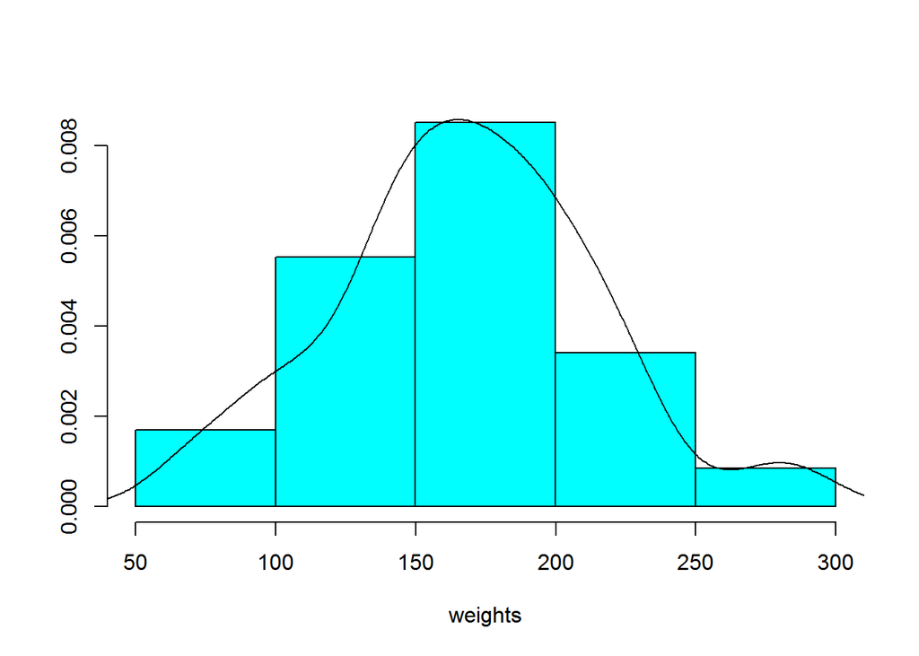

```r
# Create index16, pointing to 16-week chicks
index16 <- which(ChickWeight$Time == 16)

# Get the 16-week chick weights
weights <- ChickWeight$weight[index16]

# Plot the normalized histogram
truehist(weights)

# Add the density curve to the histogram

lines(density(weights))
```

### Using the qqPlot() function to see many details in data

A practical limitation of both histograms and density estimates is that, if we want to know whether the Gaussian distribution assumption is reasonable for our data, it is difficult to tell.

The quantile-quantile plot, or QQ-plot, is a useful alternative: we sort our data, plot it against a specially-designed x-axis based on our reference distribution (e.g., the Gaussian “bell curve”), and look to see whether the points lie approximately on a straight line. In R, several QQ-plot implementations are available, but the most convenient one is the qqPlot() function in the car package.

The first part of this exercise applies this function to the 16-week chick weight data considered in the last exercise, to show that the Gaussian distribution appears to be reasonable here. The second part of the exercise applies this function to another variable where the Gaussian distribution is obviously a poor fit, but the results also show the presence of repeated values (flat stretches in the plot) and portions of the data range where there are no observations (vertical “jumps” in the plot).

### INSTRUCTIONS

Load the car package to make the qqPlot() function available for use. Create the variable index16 using the which() function that selects records from the ChickWeight data frame with Time equal to 16. Create the variable weights that gives the weights of the 16-week old chicks. Apply the qqPlot() function to the weights data, noting that almost all of the points fall within the confidence intervals around the reference line, indicating a reasonable conformance with the Gaussian distribution for this data sequence. Apply the qqPlot() function to the tax variable from the Boston data frame in the MASS package.

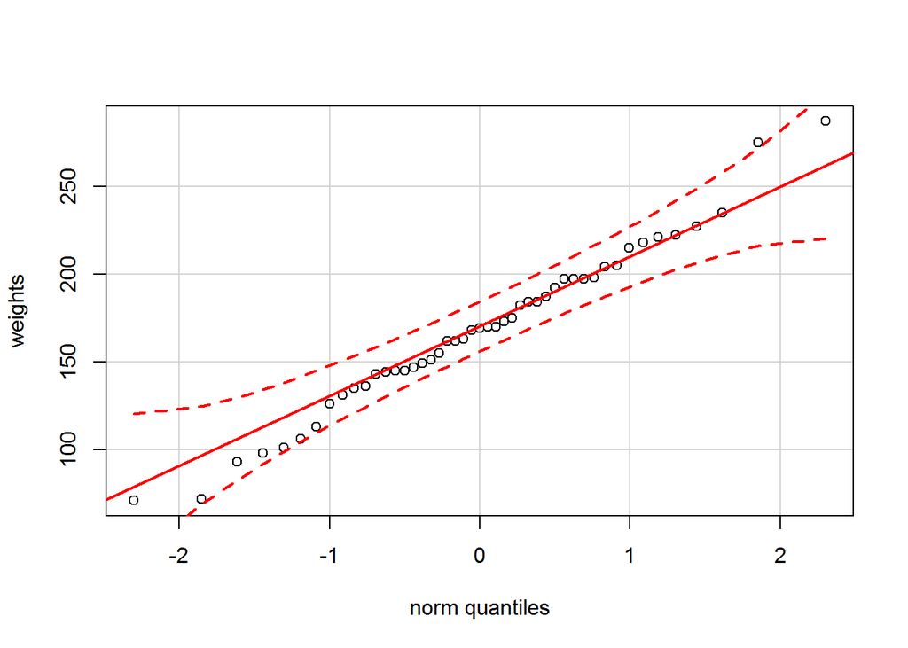

```r
# Load the car package to make qqPlot() available
library("car")

# Create index16, pointing to 16-week chicks
index16 <- which(ChickWeight$Time == 16)

# Get the 16-week chick weights
weights <- ChickWeight$weight[index16]

# Show the normal QQ-plot of the chick weights
qqPlot(weights)
```

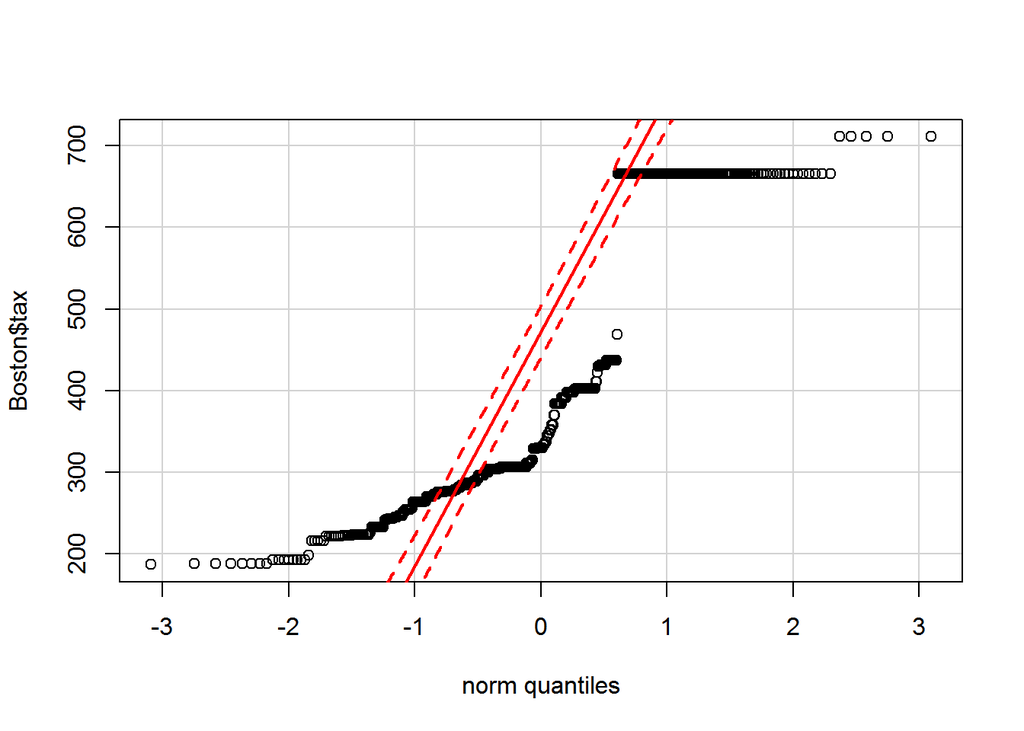

```r
# Show the normal QQ-plot of the Boston$tax data
qqPlot(Boston$tax)
```

### The sunflowerplot() function for repeated numerical data

A scatterplot represents each (x, y) pair in a dataset by a single point. If some of these pairs are repeated (i.e. if the same combination of x and y values appears more than once and thus lie on top of each other), we can’t see this in a scatterplot. Several approaches have been developed to deal with this problem, including jittering, which adds small random values to each x and y value, so repeated points will appear as clusters of nearby points.

A useful alternative that is equally effective in representing repeated data points is the sunflowerplot, which represents each repeated point by a “sunflower,” with one “petal” for each repetition of a data point.

This exercise asks you to construct both a scatterplot and a sunflowerplot from the same dataset, one that contains repeated data points. Comparing these plots allows you to see how much information can be lost in a standard scatterplot when some data points appear many times.

### INSTRUCTIONS

Use the par() function to set the mfrow parameter for a side-by-side plot array. For the left-hand plot, use the plot() function to construct a scatterplot of the rad variable versus the zn variable, both from the Boston data frame in the MASS package. Use the title() function to add the title “Standard scatterplot” to this plot. For the right-hand plot, apply the sunflowerplot() function to the same data to see the presence of repeated data points, not evident from the scatterplot on the left.

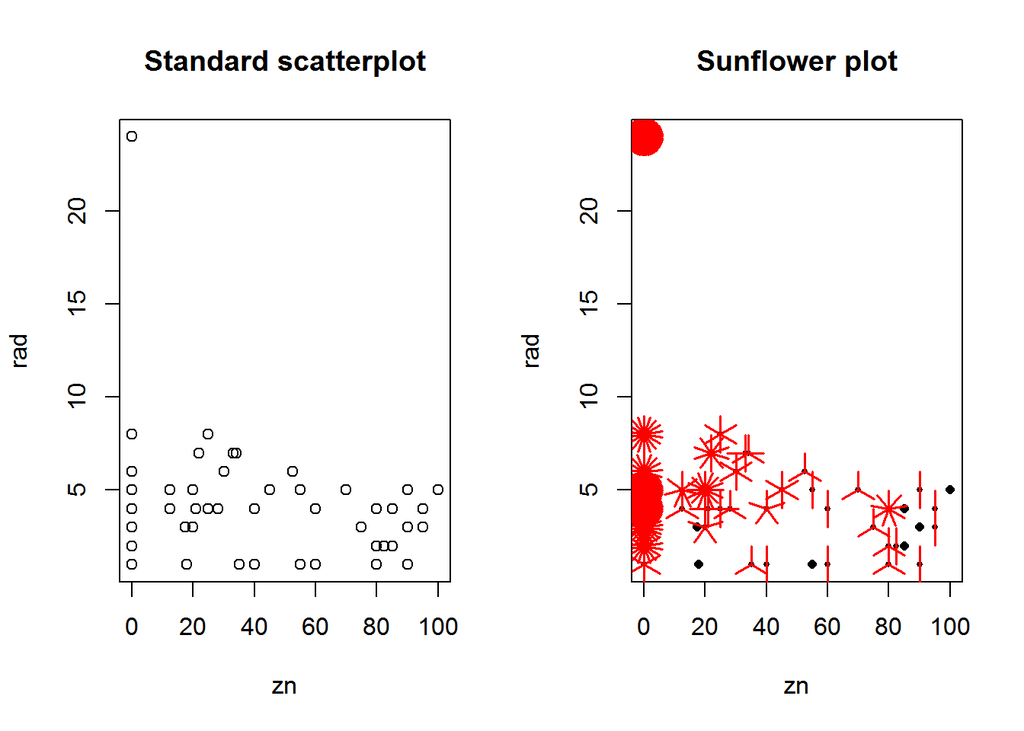

```r
# Set up a side-by-side plot array
par(mfrow = c(1,2))

# Create the standard scatterplot
plot(rad ~ zn, data = Boston)

# Add the title
title("Standard scatterplot")

# Create the sunflowerplot
sunflowerplot(rad ~ zn, data = Boston)

# Add the title
title("Sunflower plot")
```

### Useful options for the boxplot() function

The boxplot() function shows how the distribution of a numerical variable y differs across the unique levels of a second variable, x. To be effective, this second variable should not have too many unique levels (e.g., 10 or fewer is good; many more than this makes the plot difficult to interpret).

The boxplot() function also has a number of optional parameters and this exercise asks you to use three of them to obtain a more informative plot:

varwidth allows for variable-width boxplots that show the different sizes of the data subsets. log allows for log-transformed y-values. las allows for more readable axis labels. This exercise also illustrates the use of the formula interface: y ~ x indicates that we want a boxplot of the y variable across the different levels of the x variable. See ?boxplot for more details.

### INSTRUCTIONS

Using the formula interface, create a boxplot showing the distribution of numerical crim values over the different distinct rad values from the Boston data frame. Use the varwidth parameter to obtain variable-width boxplots, specify a log-transformed y-axis, and set the las parameter equal to 1 to obtain horizontal labels for both the x- and y-axes. Use the title() function to add the title “Crime rate vs. radial highway index”.

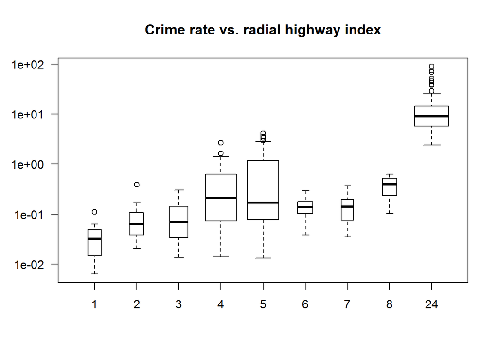

```r
# Create a variable-width boxplot with log y-axis & horizontal labels
boxplot(crim ~ rad, data = Boston, varwidth = TRUE, log = "y", las =1 )

# Add a title
title("Crime rate vs. radial highway index")
```

### Using the mosaicplot() function

A mosaic plot may be viewed as a scatterplot between categorical variables and it is supported in R with the mosaicplot() function.

As this example shows, in addition to categorical variables, this plot can also be useful in understanding the relationship between numerical variables, either integer- or real-valued, that take only a few distinct values.

More specifically, this exercise asks you to construct a mosaic plot showing the relationship between the numerical carb and cyl variables from the mtcars data frame, variables that exhibit 6 and 3 unique values, respectively.

### INSTRUCTIONS

Apply the mosaicplot() function with the formula interface to see how the levels of the carb variable vary with the levels of the cyl variable from the mtcars data frame.

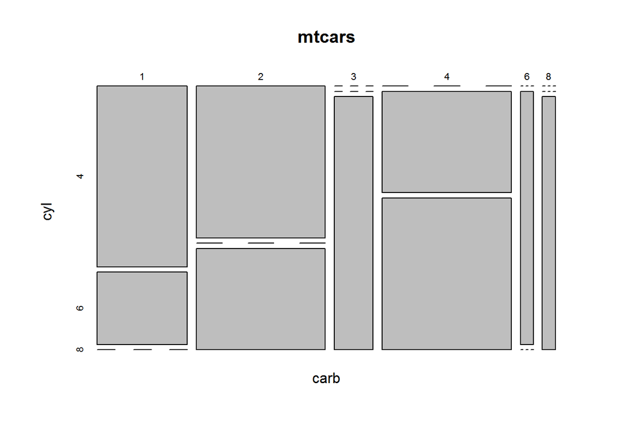

```r
# Create a mosaic plot using the formula interface
mosaicplot(carb ~ cyl, data = mtcars)
```

### Using the bagplot() function

A single box plot gives a graphical representation of the range of variation in a numerical variable, based on five numbers:

The minimum and maximum values The median (or “middle”) value Two intermediate values called the lower and upper quartiles In addition, the standard box plot computes a nominal data range from three of these numbers and flags points falling outside this range as outliers, representing them as distinct points.

The bag plot extends this representation to two numerical variables, showing their relationship, both within two-dimensional “bags” corresponding to the “box” in the standard boxplot, and indicating outlying points outside these limits.

### INSTRUCTIONS

Use the boxplot() function to construct side-by-side box plots for Min.Price and Max.Price from the Cars93 data frame. Load the aplpack package to make the bagplot() function available. Construct the bag plot showing the relationship between the Min.Price and Max.Price variables from the Cars93 data frame. Use the cex parameter to make the point sizes in this plot 20 percent larger than the default size. Use the abline() function to add a dashed equality reference line with intercept 0 and slope 1.

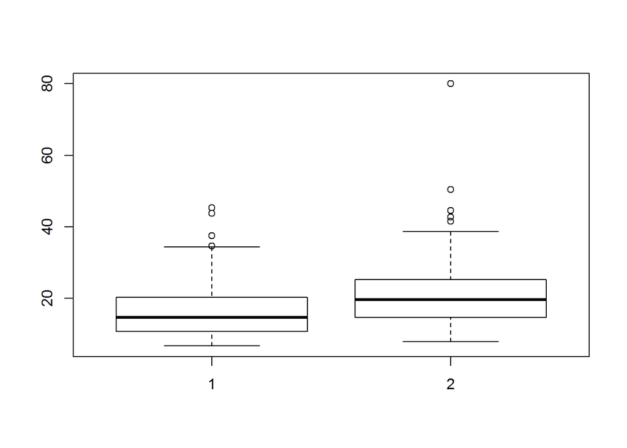

```r
# Create a side-by-side boxplot summary
boxplot(Cars93$Min.Price, Cars93$Max.Price)
```

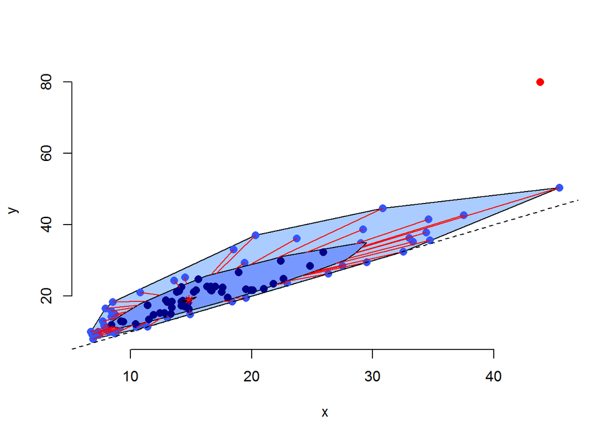

```r
# Load aplpack to make the bagplot() function available
library("aplpack")
# Create a bagplot for the same two variables
bagplot(Cars93$Min.Price, Cars93$Max.Price, cex = 1.2)

# Add an equality reference line
abline(a=0, b=1, lty = 2)
```

### Plotting correlation matrices with the corrplot() function

Correlation matrices were introduced in the video as a useful tool for obtaining a preliminary view of the relationships between multiple numerical variables.

This exercise asks you to use the corrplot() function from the corrplot package to visualize this correlation matrix for the numerical variables from the UScereal data frame in the MASS package. Recall that in this version of these plots, ellipses that are thin and elongated indicate a large correlation value between the indicated variables, while ellipses that are nearly circular indicate correlations near zero.

### INSTRUCTIONS

Create a subset of the UScereal data frame that contains only the 9 numerical (i.e., non-factor) variables. Save the result as numericalVars. Apply the cor() function to this subset to compute the correlation matrix containing the correlation coefficients between all variable pairs. Save the result as corrMat. Apply the corrplot() function to display this correlation matrix, using the “ellipse” method. Which two variables are most highly correlated with potassium?

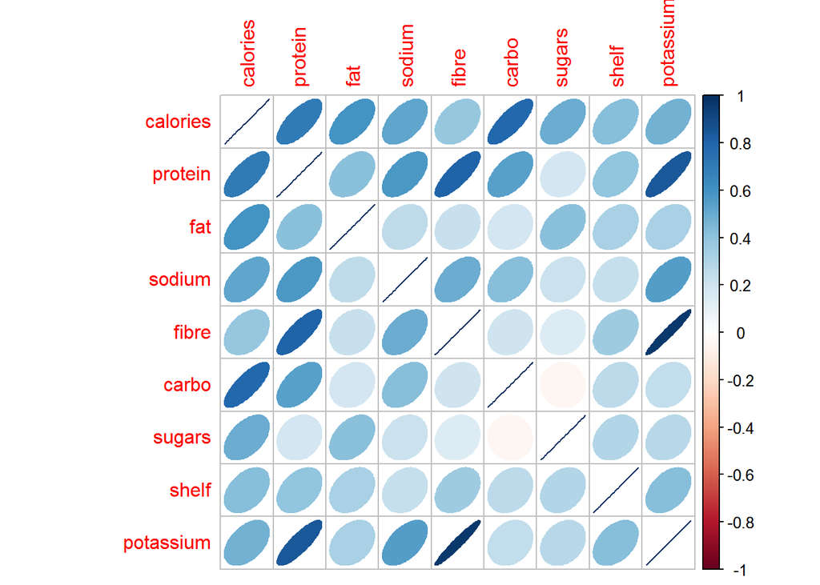

```r
# Load the corrplot library for the corrplot() function
library("corrplot")
# Extract the numerical variables from UScereal
numericalVars <- UScereal[,2:10]

# Compute the correlation matrix for these variables
corrMat <- cor(numericalVars)

# Generate the correlation ellipse plot
corrplot(corrMat, method = "ellipse" )
```

### Building and plotting rpart() models

It was noted in the video that decision trees represent a popular form of predictive model because they are easy to visualize and explain. It was also noted that the rpart package is probably the most popular of several R packages that can be used to build and visualize these models.

This exercise asks you to, first, build a decision tree model using the rpart() function from this package, and then display the resulting model structure using the generic functions plot() and text().

### INSTRUCTIONS

Load the rpart package to make the rpart() modeling function and the associated methods for generic functions like plot() available. Use the rpart() function to fit a decision tree model tree_model that predicts medv in the Boston data frame from all of the other variables in this data frame. Apply the plot() function to tree_model to obtain an unlabelled plot of the structure of this decision tree model. Apply the text() function to tree_model to label this plot. To make the labels easier to read, use the cex parameter to reduce the text to 70% of the default size.

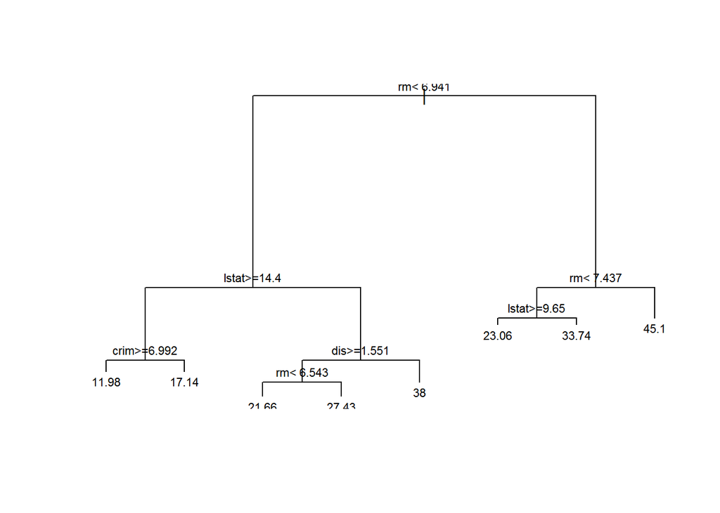

```r
# Load the rpart library
library("rpart")

# Fit an rpart model to predict medv from all other Boston variables
tree_model <- rpart(medv ~ ., data = Boston )

# Plot the structure of this decision tree model
plot(tree_model)

# Add labels to this plot
text(tree_model, cex = .7)
```

## Adding details to plots

Most base R graphics functions support many optional arguments and parameters that allow us to customize our plots to get exactly what we want. In this chapter, we will learn how to modify point shapes and sizes, line types and widths, add points and lines to plots, add explanatory text and generate multiple plot arrays.

### Introduction to the par() function

You already saw how the mfrow parameter to the par() function could be used to plot multiple graphs in one pane. The par() function also allows you to set many other graphics parameters, whose values will remain in effect until they are reset by a subsequent par() call.

Specifically, a call to the par() function with no parameters specified will return a list whose element names each specify a graphics parameter and whose element values specify the corresponding default values of these parameters. These parameters may be set by a call in the form par(name = value) where name is the name of the parameter to be set and value is the value to be assigned to this parameter.

The purpose of this exercise is to give an idea of what these graphics parameters are. In the subsequent exercises we’ll show how some of these parameters can be used to enhance plot results.

### INSTRUCTIONS

```r
# Assign the return value from the par() function to plot_pars
plot_pars <- par()

# Display the names of the par() function's list elements
names(plot_pars)
```

```
##  [1] "xlog"      "ylog"      "adj"       "ann"       "ask"
##  [6] "bg"        "bty"       "cex"       "cex.axis"  "cex.lab"
## [11] "cex.main"  "cex.sub"   "cin"       "col"       "col.axis"
## [16] "col.lab"   "col.main"  "col.sub"   "cra"       "crt"
## [21] "csi"       "cxy"       "din"       "err"       "family"
## [26] "fg"        "fig"       "fin"       "font"      "font.axis"
## [31] "font.lab"  "font.main" "font.sub"  "lab"       "las"
## [36] "lend"      "lheight"   "ljoin"     "lmitre"    "lty"
## [41] "lwd"       "mai"       "mar"       "mex"       "mfcol"
## [46] "mfg"       "mfrow"     "mgp"       "mkh"       "new"
## [51] "oma"       "omd"       "omi"       "page"      "pch"
## [56] "pin"       "plt"       "ps"        "pty"       "smo"
## [61] "srt"       "tck"       "tcl"       "usr"       "xaxp"
## [66] "xaxs"      "xaxt"      "xpd"       "yaxp"      "yaxs"
## [71] "yaxt"      "ylbias"
```

```r
# Display the number of par() function list elements
length(plot_pars)
```

```
## [1] 72
```

### Exploring the type option

A more detailed discussion of using the mfrow parameter is given in Chapter 4 of this course. For now, note that to specify a plot array with three rows and one column, the command would be par(mfrow = c(3, 1)).

The following exercise also introduces the type parameter for the plot() command, which specifies how the plot is drawn. The specific type values used here are:

“p” for “points” “l” for “lines” “o” for “overlaid” (i.e., lines overlaid with points) “s” for “steps”

### INSTRUCTIONS

Use the par() function to set the mfrow parameter for a two-by-two plot array. Generate a plot of brain weights from the Animals2 data frame, with observations plotted as points and the title “points” by calling the title() function. Repeat, with observations plotted as lines and the title “lines”. Repeat, with observations plotted as overlaid points and lines and the title “overlaid”. Repeat, with observations plotted as steps and the title “steps”.

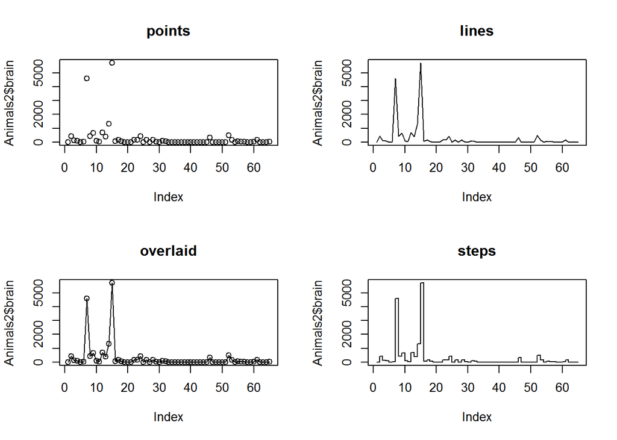

```r
# Set up a 2-by-2 plot array
par(mfrow = c(2,2))

# Plot the Animals2 brain weight data as points
plot(Animals2$brain, type = "p")

# Add the title
title("points")

# Plot the brain weights with lines
plot(Animals2$brain, type = "l")

# Add the title
title("lines")

# Plot the brain weights as lines overlaid with points
plot(Animals2$brain, type = "o")

# Add the title
title("overlaid")

# Plot the brain weights as steps
plot(Animals2$brain, type = "s")

# Add the title
title("steps")
```

### The surprising utility of the type “n” option

The type = “n” option was discussed in the video and this exercise provides a simple example. This option is especially useful is when we are plotting data from multiple sources on a common set of axes. In such cases, we can compute ranges for the x- and y-axes so that all data points will appear on the plot, and then add the data with subsequent calls to points() or lines() as appropriate.

This exercise asks you to generate a plot that compares mileage vs. horsepower data from two different sources: the mtcars data frame in the datasets package and the Cars93 data frame in the MASS package. To distinguish the different results from these data sources, the graphics parameter pch is used to specify point shapes. See ?points for a comprehensive list of some pch values and their corresponding point shapes.

### INSTRUCTIONS

Compute max_hp as the maximum of Horsepower from the Cars93 data frame and hp from the mtcars data frame. Compute max_mpg as the maximum of MPG.city from the Cars93 data frame, MPG.highway from this data frame, and mpg from the mtcars data frame. Using the type = “n” option, set up a plot with an x-axis that runs from zero to max_hp and a y-axis that runs from zero to max_mpg, with labels Horsepower and Miles per gallon. Using the points() function, add mpg vs. hp from the mtcars data frame to the plot as open circles (pch = 1). Using the points() function, add MPG.city vs. Horsepower to the plot as solid squares (refer to the plot of pch values). Using the points() function, add MPG.highway vs. Horsepower to the plot as open triangles pointing upwards (refer to the plot of pch values).

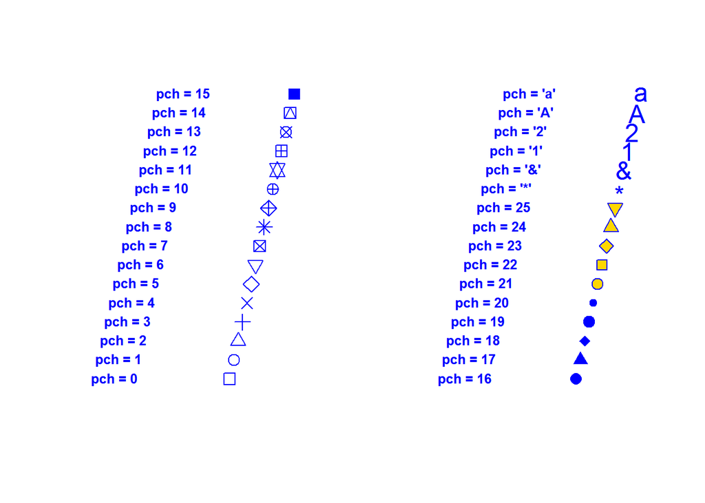

```r
pchExamples <- function(textCol = "blue", textSize = 0.8,
                        ptCol = "blue", bgCol = "gold", ptSize = 1.5){
                        #
                        pchChars <- c("*", "&", "1", "2", "A", "a")
                        pchSeq <- append(as.list(0:25), as.list(pchChars))
                        xseq <- seq(1, 32, 1)
                        labelString <- vector("character", 32)
                        labelString[1:26] <- paste("pch = ", 0:25, sep = "")
                        labelString[27:32] <- paste("pch = ", "'", pchChars, "'", sep = "")
                        n <- 32
                        nHalf <- 16
                        nQuart <- 8
                        xseq <- seq(1, n, 1)
                        #
                        plot(xseq, xseq, type = "n", axes = FALSE, xlab = "", ylab = "")
                        for (i in 1:nHalf){
                                text(xseq[i]/4, 2*xseq[i], labelString[i], adj = 0, font = 2,
                                col = textCol, cex = textSize)
                                points(xseq[i]/4 + nQuart, 2*xseq[i], pch = pchSeq[[i]], col = ptCol,
                                bg = bgCol, cex = ptSize)
                          }
                          for (i in (nHalf + 1):n){
                            text(xseq[i]/4 + 2*nQuart, 2*(xseq[i] - nHalf), labelString[i],
                                 adj = 0, font = 2, col = textCol, cex = textSize)
                            points(xseq[i]/4 + 3*nQuart, 2*(xseq[i] - nHalf), pch = pchSeq[[i]],
                                   col = ptCol, bg = bgCol, cex = ptSize)
                            }
                        }
                            pchExamples()
```

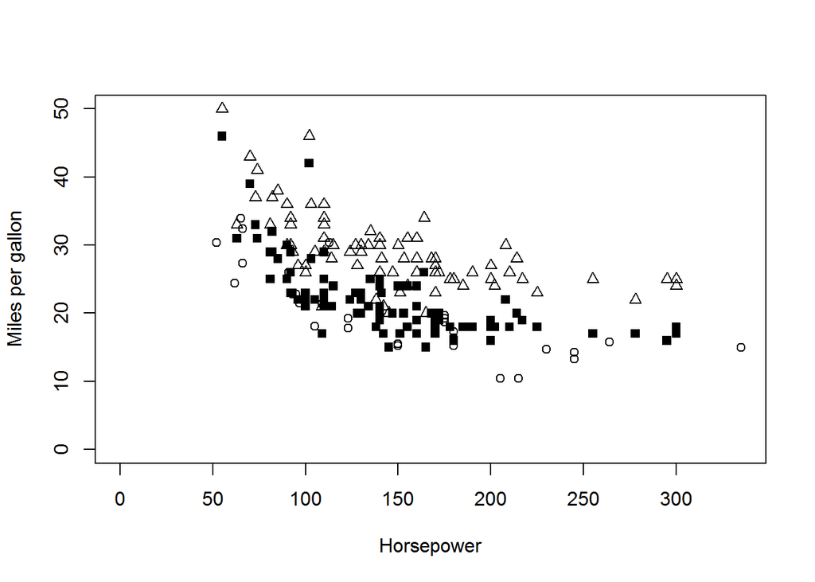

```r
# Compute max_hp
max_hp <- max(Cars93$Horsepower, mtcars$hp )

# Compute max_mpg
max_mpg <- max(Cars93$MPG.city,  Cars93$MPG.highway, mtcars$mpg)

# Create plot with type = "n"
plot(Cars93$Horsepower, Cars93$MPG.city,
     type = "n",
     xlim = c(0, max_hp),
     ylim = c(0, max_mpg),
     xlab = "Horsepower",
     ylab = "Miles per gallon")

# Add open circles to plot
points(mtcars$hp, mtcars$mpg, pch = 1)

# Add solid squares to plot
points(Cars93$Horsepower, Cars93$MPG.city, pch = 15)

# Add open triangles to plot
points(Cars93$Horsepower, Cars93$MPG.highway, pch = 2)
```

The curves you are asked to draw here have the same basic shape but differ in their details (specifically, the means and standard deviations of these Gaussian distributions are different). For this reason, it is useful to draw these curves with different line types to help us distinguish them.

Note that line types are set by the lty argument, with the default value lty = 1 specifying solid lines, lty = 2 specifying dashed lines, and lty = 3 specifying dotted lines. Also note that the lwd argument specifies the relative width.

INSTRUCTIONS 100XP Create a numerical variable x with 200 evenly-spaced values from 0 to 10. Using the dnorm() function, generate a vector gauss1 of Gaussian probability densities for this range of x values, with mean 2 and standard deviation 0.2. Using the dnorm() function, generate a vector gauss2 of Gaussian probability densities for this range of x values, with mean 4 and standard deviation 0.5. Generate a plot of gauss1 vs. x with lines and a y-axis label “Gaussian probability density”. Using the lines() function, add a second dashed line for gauss2 vs. x with relative width 3 (refer to the line type plot to select the lty parameter).

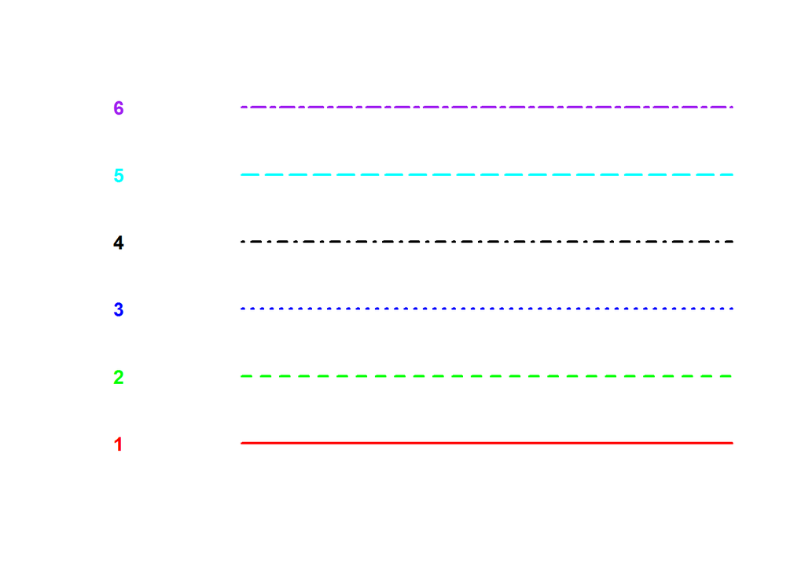

```r
# pec
ltyExamples <- function(){  #
  lineTypes <- 1:6
lineColors <- c("red", "green", "blue",
"black", "cyan", "purple")
plot(lineTypes, lineTypes, type = "n",
axes = FALSE, xlab = "", ylab = "")
segments(2, lineTypes, 6, lineTypes, lwd = 2,
         lty = lineTypes, col = lineColors)
text(1, lineTypes, lineTypes, font = 2,
     col = lineColors)
}
ltyExamples()
```

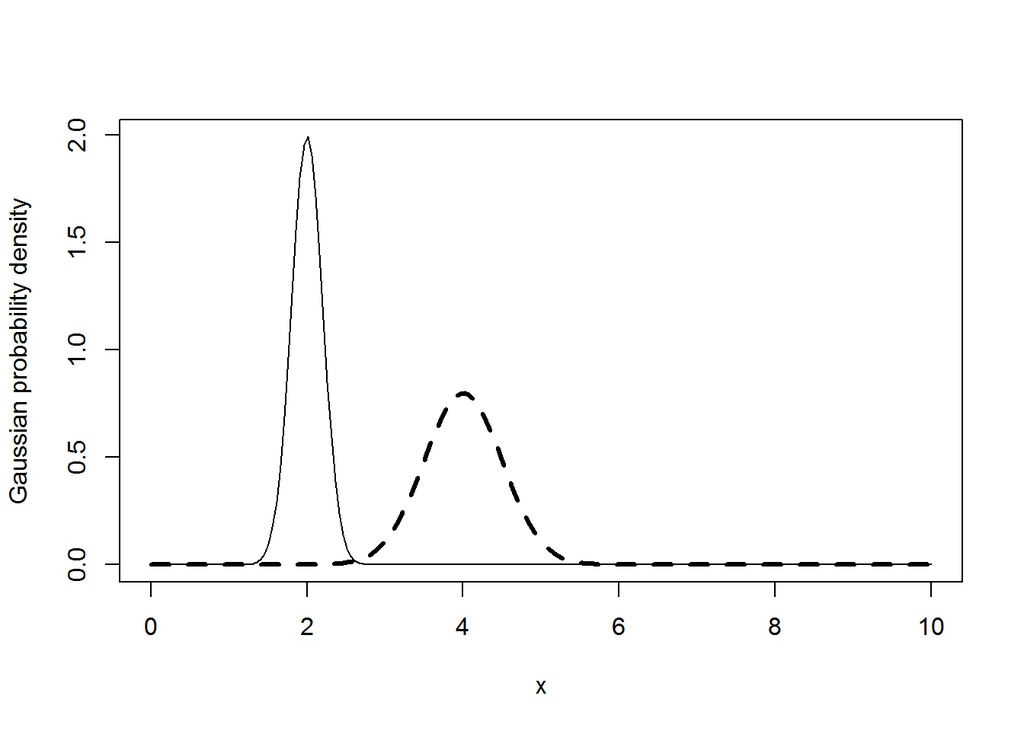

```r
# Create the numerical vector x
x <- seq(0, 10, length = 200)

# Compute the Gaussian density for x with mean 2 and standard deviation 0.2
gauss1 <- dnorm(x, mean = 2, sd = .2)

# Compute the Gaussian density with mean 4 and standard deviation 0.5
gauss2 <- dnorm(x, mean = 4, sd = .5)

# Plot the first Gaussian density
plot(x, gauss1, type ="l", ylab = "Gaussian probability density")

# Add lines for the second Gaussian density
lines(x, gauss2, lty=2, lwd=3)
```

### The points() function and point types

One advantage of specifying the pch argument locally is that, in a call to functions like plot() or points(), local specification allows us to make pch depend on a variable in our dataset. This provides a simple way of indicating different data subsets with different point shapes or symbols.

This exercise asks you to generate two plots of mpg vs. hp from the mtcars data frame in the datasets package. The first plot specifies the point shapes using numerical values of the pch argument defined by the cyl variable in the mtcars data frame. The second plot illustrates the fact that pch can also be specified as a vector of single characters, causing each point to be drawn as the corresponding character.

### INSTRUCTIONS

Create an empty plot of mpg vs. hp using the type = “n” option from the mtcars data frame, with axis labels “Horsepower” and “Gas mileage”. Using the points() function, add the mpg vs. hp data, with pch specified by the numeric values of cyl. Repeat both of the previous steps, except with pch specified by the character values of cyl.

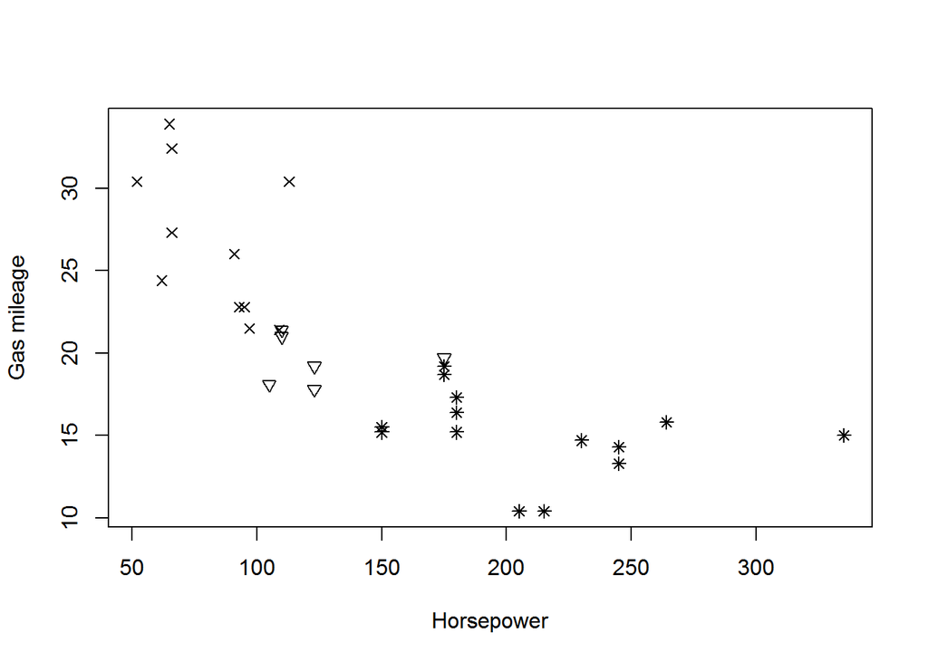

```r
# Create an empty plot using type = "n"
plot(mtcars$hp, mtcars$mpg, type = "n", xlab = "Horsepower", ylab = "Gas mileage")

# Add points with shapes determined by cylinder number
points(mtcars$hp, mtcars$mpg, pch = mtcars$cyl)
```

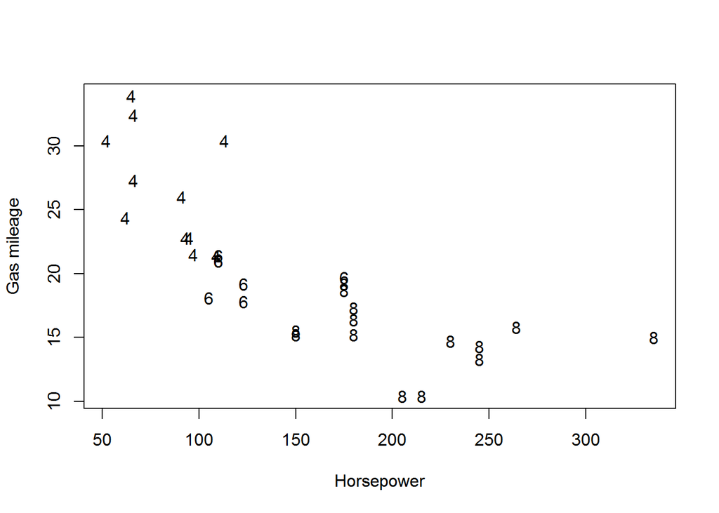

```r
# Create a second empty plot
plot(mtcars$hp, mtcars$mpg, type = "n", xlab = "Horsepower", ylab = "Gas mileage")


# Add points with shapes as cylinder characters
points(mtcars$hp, mtcars$mpg, pch = as.character(mtcars$cyl))
```

### Adding trend lines from linear regression models

The low-level plot function abline() adds a straight line to an existing plot. This line is specified by an intercept parameter a and a slope parameter b, and the simplest way to set these parameters is directly. For example, the command abline(a = 0, b = 1) adds an equality reference line with zero intercept and unit (i.e. 1) slope: points for which y = x fall on this reference line, while points with y > x fall above it, and points with y < x fall below it.

An alternative way of specifying these parameters is through a linear regression model that determines them from data. One common application is to generate a scatterplot of y versus x, then fit a linear model that predicts y from x, and finally call abline() to add this best fit line to the plot.

This exercise asks you to do this for the Gas versus Temp data from the whiteside data frame in the MASS package. The standard R function that fits linear regression models is lm(), which supports the formula interface. Thus, to fit a linear model that predicts y from x in the data frame df, the call would be lm(y ~ x, data = df). This call returns a linear model object, which can then be passed as an argument to the abline() function to draw the desired line on our plot.

### INSTRUCTIONS

Use the lm() function to create linear_model, a linear regression model that predicts Gas from Temp from the whiteside data frame. Generate a scatterplot of Gas vs. Temp. Using the abline() function, add a dashed reference line that shows the predictions of linear_model.

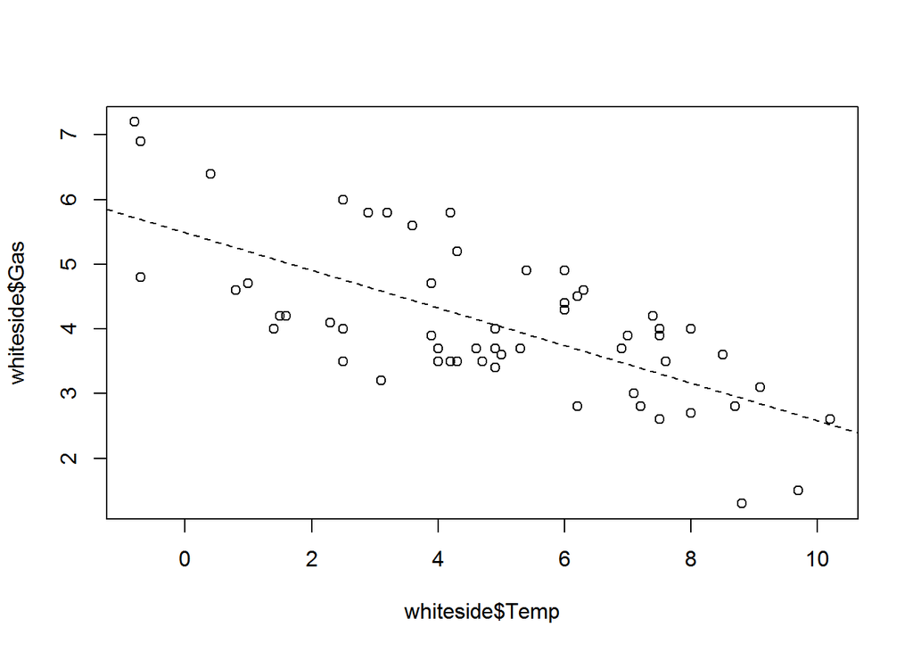

```r
# Build a linear regression model for the whiteside data
linear_model <- lm (Gas ~ Temp, data = whiteside)

# Create a Gas vs. Temp scatterplot from the whiteside data
plot(whiteside$Temp, whiteside$Gas)

# Use abline() to add the linear regression line
abline(linear_model, lty = 2 )
```

### Using the text() function to label plot features

One of the main uses of the text() function is to add informative labels to a data plot. The text() function takes three arguments:

x, which specifies the value for the x variable, y, which specifies the value for the y variable, and label, which specifies the label for the x-y value pair. This exercise asks you to first create a scatterplot of city gas mileage versus horsepower from the Cars93 data, then identify an interesting subset of the data (i.e. the 3-cylinder cars) and label these points. You will find that assigning a vector to the x, y, and label arguments to text() will result in labeling multiple points at once.

### INSTRUCTIONS

Create a scatterplot of MPG.city vs. Horsepower from the Cars93 data frame, with points represented as solid squares. Recall that the pch value for solid squares is 15. Create the variable index3 using the which() function that identifies all 3-cylinder cars. Label the Make of each 3-cylinder car in the Cars93 data frame using the text() function. Use the adj argument to specify left-justified text in your labels. Use the zoom feature in the Plots window to see this plot more clearly.

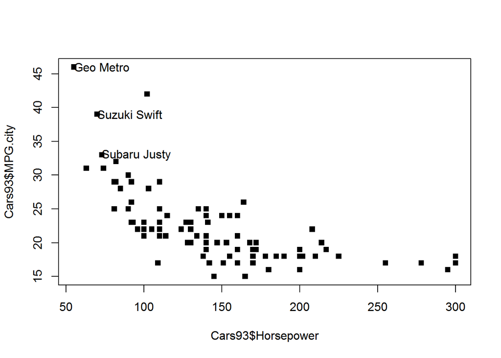

```r
# Create MPG.city vs. Horsepower plot with solid squares
plot(Cars93$Horsepower, Cars93$MPG.city, pch = 15)

# Create index3, pointing to 3-cylinder cars
index3 <- which(Cars93$Cylinders == 3)

# Add text giving names of cars next to data points
text(x = Cars93$Horsepower[index3],
     y = Cars93$MPG.city[index3],
     labels = Cars93$Make[index3], adj = 0)
```

### Adjusting text position, size, and font

The previous exercise added explanatory text to a scatterplot. The purpose of this exercise is to improve this plot by modifying the text placement, increasing the text size, and displaying the text in boldface.

It was noted that the adj argument to the text() function determines the horizontal placement of the text and it can take any value between 0 and 1. In fact, this argument can take values outside this range. That is, making this value negative causes the text to start to the right of the specified x position. Similarly, making adj greater than 1 causes the text to end to the left of the x position.

Another useful optional argument for the text() function is cex, which scales the default text size. As a specific example, setting cex = 1.5 increases the text size by 50 percent, relative to the default value. Similarly, specifying cex = 0.8 reduces the text size by 20 percent.

Finally, the third optional parameter used here is font, which can be used to specify one of four text fonts: font = 1 is the default text font (neither italic nor bold), font = 2 specifies bold face text, font = 3 specifies italic text, and font = 4 specifies both bold and italic text.

### INSTRUCTIONS

Create a plot of MPG.city vs. Horsepower from the Cars93 data frame, with data represented as open circles. Construct the variable index3 using the which() function that identifies the row numbers containing all 3-cylinder cars. Use the points() function to overlay solid circles on top of all points in the plot that represent 3-cylinder cars. Use the text() function with the Make variable as before to add labels to the right of the 3-cylinder cars, but now use adj = -0.2 to move the labels further to the right, use the cex argument to increase the label size by 20 percent, and use the font argument to make the labels bold italic.

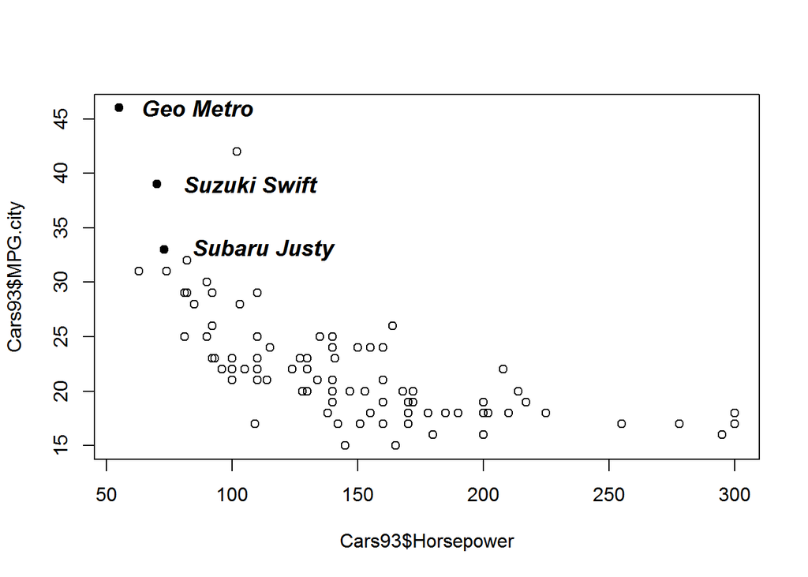

```r
# Plot MPG.city vs. Horsepower as open circles
plot(Cars93$Horsepower, Cars93$MPG.city, pch = 1)

# Create index3, pointing to 3-cylinder cars
index3 <- which(Cars93$Cylinders == 3)

# Highlight 3-cylinder cars as solid circles
points(Cars93$Horsepower[index3], Cars93$MPG.city[index3], pch = 16)

# Add car names, offset from points, with larger bold text
text(x = Cars93$Horsepower[index3], y = Cars93$MPG.city[index3], labels = Cars93$Make[index3], adj = -0.2, cex = 1.2, font = 4)
```

### Rotating text with the srt argument

In addition to the optional arguments used in the previous exercises, the text() function also supports a number of other optional arguments that can be used to enhance the text. This exercise uses the cex argument to reduce the text size and introduces two new arguments. The first is the col argument that specifies the color used to display the text, and the second is the srt argument that allows us to rotate the text.

Color has been used in several of the previous exercises to specify point colors, and the effective use of color is discussed further in Chapter 5. One of the points of this exercise is to show that the specification of text color with the text() function is essentially the same as the specification of point color with the plot() function. As a specific example, setting col = “green” in the text() function causes the text to appear in green. If col is not specified, the text appears in the default color set by the par() function, which is typically black.

The srt parameter allows us to rotate the text through an angle specified in degrees. The typical default value (set by the par() function) is 0, causing the text to appear horizontally, reading from left to right. Specifying srt = 90 causes the text to be rotated 90 degrees counter-clockwise so that it reads from bottom to top instead of left to right.